# Practice Final Problems

### Problem 5.

#### Part (a)

**Why would you use a bootstrap confidence interval instead of a normal-based confidence interval for testing the following hypotheses for any arbitrary dataset?**

$$H_0: m=100$$

versus

$$H_1: m \neq 100$$

where $m$ is the true median of our population.

#### Part (b)

**Which of the following distributions do you simulate/estimate in order to create a bootstrap confidence interval?**

$\bigcirc$ Distribution under the $H_0$

$\bigcirc$ Distribution under the alternative hypothesis

**ANSWER** Sampling distribution of $m$

$\bigcirc$ Normal curve

#### Part (c)

**Which of the functions is used when finding the upper and lower bound for a bootstrap confidence interval?**

**ANSWER** `quantile()`

$\bigcirc$ `bootstrap()`

$\bigcirc$ `aov()`

$\bigcirc$ `summary()`

### Problem 6.

**Figure out the type of test you’re going to use based on the problem. Then, carry out the test.**

#### Part (a)

**We have data on the birth years of presidents and their first people. Here is a random sample of that data.**

| president | first_person |
| --- | --- |
| 1924 | 1925 |
| 1882 | 1884 |
| 1946 | 1947 |
| 1843 | 1847 |
| 1890 | 1896 |
| 1917 | 1929 |
| 1795 | 1803 |
| 1857 | 1861 |
| 1809 | 1818 |
| 1913 | 1912 |

**What kind of variables are in these columns?**  
Year is like age to time (in this case). Time is continuous, age is continuous, year is continuous (in this case).

**We are interested in knowing whether the president tends to be older than their first person. What hypothesis might we test? It may be helpful to have the following output to answer the question.**

```r
dim(presidents)
```

```
## [1] 44  2
```

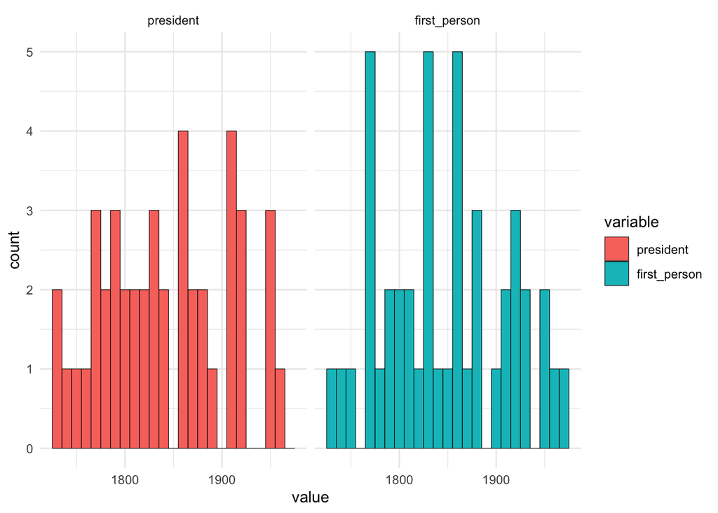

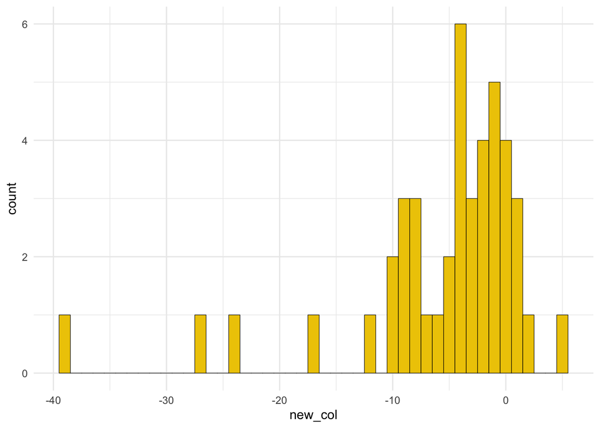

```r
presidents <- presidents %>% mutate(new_col=president-first_person)
ggplot(presidents, aes(x=new_col)) +
  geom_histogram(binwidth=1, col="black", fill="gold2", lwd=0.2) +
  theme_minimal()
```

We are interested in testing

**What tests can you use? (Hint: There’s more than one, but one will give you better results in this case.)**

Because we have $n=44$ for each of the groups, assume randomness, and have distributions of similar shapes, we’d opt for a one-sided paired t-test. The paired t-test will give you better results than a nonparametric test because we are able to use theoretical distributions as opposed to rankings (which lose information/power).

#### Part (b)

**On Thursday mornings, an online shopper attempts to buy an item from the Supreme brand website. Say that probability of successfully purchasing an item on a given Thursday is 20%.**

**How many times per month do we expect the shopper to successfully order something?**  
Assuming all months have 4 Thursdays, then we would expect 0.8 successes per month. This is, in practical terms, 0 successes.

```r
0.2*4
```

```
## [1] 0.8
```

**What is the probability that the shopper will successfully order an item three Thursdays in a row?**

```r
0.2^3
```

```
## [1] 0.008
```

**What is the probability that the shopper will successfully order 2 items during the span of three Thursdays?**

```r
choose(3,2)*(0.2)^3*(1-0.2)
```

```
## [1] 0.0192
```

**Our shopper believes that it’s getting even more difficult to purchase an item off of the Supreme brand website lately. He and 30 of his friends decide to all try to purchase an item. Out of his group of friends and himself, 10 of them are able to purchase an item. Does the shopper have evidence that the probability of purchasing an item on a given Thursday is still 20%?**

A status-quo belief is that $P(\text{Success})=0.2$. A competing belief is that $P(\text{Success})=10/31$. We want to test the following hypotheses.

$$H_0: p=0.2$$

versus

$$H_0: p \neq 0.2.$$

Our $\hat{p}=10/31$. Do we meet assumptions for the large sample z-test for a population proportion? We assume that we have randomness. We have 10 successes and 21 failures. Let’s try.

```r
n <- 31
p_hat <- 10/31
n*p_hat
```

```
## [1] 10
```

```r
n*(1-p_hat)
```

```
## [1] 21
```

Since these values are both $\geq$ 10, and we assume that our population is at least 20 times larger than 31, we’ll go ahead and do a large sample z-test.

```r
p_0 <- 0.2
se  <- sqrt(p_hat*(1-p_hat)/n)

z   <- (p_hat - p_0) / se
z
```

```
## [1] 1.460007
```

Then, we’ll get our p-value.

```r
2*pnorm(1.46, lower.tail=FALSE)
```

```
## [1] 0.1442901
```

```r
2*(1-pnorm(1.46))
```

```
## [1] 0.1442901
```

We **interpret** this p-value to mean if the true probability of success was really 0.2, then we would expect to see our data or more extreme 14.429% of the time just by random chance.

Because this value is not so small (it is greater than 10%, greater than 5%, greater than 1%), we fail to reject the null hypothesis!

To answer the question: No. There is no evidence.

#### Part (c)

**We have conducted an ANOVA test between 5 different groups of friends and tested how quickly they could climb up a standard gym class rope. Our ANOVA test gave us a p-value of 0.0008.**

**How do we interpret the p-value?**  
Given that the mean rope times of the 5 different groups are truly the same, we would expect to see our observations or observations yielding more extreme results 0.08% of the time.

**Can we tell which groups over/under-performed?**  
Not just by an ANOVA test. We’d need to do post-hoc procedures to figure this out.

### Problem 7.

**Here are a bunch of “pop” questions to test your knowledge.**

**- True or false. If two events are independent, then they are mutually exclusive.**  
False.

**- What are the two types of categorical variables? Give examples.**  
Nominal and ordinal.

**- Is age continuous or discrete?**  
Continuous.

**- True or false. If my null hypothesized value of $\mu$ is not within my confidence interval, then my p-value is less than my significance level $\alpha$.**  
True. If $\mu_0$ is not in our CI, then we are rejecting our null hypothesis. So, our p-value would be less $\alpha$ because when our p-value is small, we reject our null.

**- What do we always expect of our data in statistical inference?**  
To be pulled randomly.

**- True or false. Correlation can be below 0.**  
True.

**- Does correlation make a distinction between explanatory and response variables?**  
No.

**- Under what conditions would we use the plus-four method?**  
When normality doesn’t kick-in. Short answer, $n$ is 20x smaller than population, $n\hat{p}$ and $n(1-\hat{p})$ are both at least 10.

**- In what ways can we increase the F statistic? (Theoretical is fine.)**  
- Decrease standard deviation within groups.  
- Make the means of each of the groups further from each other.

(Not really an answer, but side note: to give our F statistic even more evidence, increase sample size.)

**- Why do we learn 4 different methods to create CI for proportions? Which one would you use with small $n$?**  
Because our sample size and prooportions don’t always satisfy the large sample assumptions.

**- Imagine we are doing a z-test for two proportions. What can be changed to make the confidence interval more narrow?**  
- Your confidence level should decrease.  
- Sample size increases.  
- If SE were smaller (though we can’t change this for real), then the CI would get smaller.

### Problem 8.

**Do the Bill Nye question on page 3 of [this document](https://palautatan.github.io/ph142/notes/testing/ci-and-z.pdf).**  
Solutions are provided on the document.

### Problem 9.

You are testing

$$H_0: \mu = 10$$

versus

$$H_1: \mu < 10$$

with data from an underlying normal distribution. Your data are as follows.

```r
dim(data)
```

```
## [1] 25  1
```

```r
data %>% summarize(mean=mean(data))
```

```
##       mean
## 1 9.078532
```

**Are we calculating a z or t statistic?**  
t. We don’t have $\sigma$.

**What parameter(s) are relevant for the distribution that we plan to calcualte our p-value from? Give exact value(s).**  
Degrees of freedom, i.e. $n-1$ for this case. That is $25-1$.

### Problem 10.

**You plan to ask a random sample of San Franciscans their opinion on whether coffee is the best beverage.**

**How many San Franciscans must be interviewed to estimate the population proportion to within 3 percentage points with 95% confidence? Use 0.5 as the conservative guess for $p$.**  
Recall

$$n = \bigg(\frac{z^*}{m}\bigg)^2p^*(1-p^*)$$

```r
z_star <- 1.96
m      <- 0.03
p_star <- 0.5

(z_star/m)^2*p_star*(1-p_star)
```

```
## [1] 1067.111
```

Therefore, the answer is 1068. Don’t forget to round.

**Would the sample size have to increase or decrease if we changed the desired margin of error from 3 percentage points to 2 percentage points? You do not have to calculate your answer.**  
The sample size would have to increase. Smaller margins of error call for larger samples. Notice that in the equation

$$n = \bigg(\frac{z^*}{m}\bigg)^2p^*(1-p^*)$$

$m$ is in the denominator. If we have $m$ be smaller, then we have an overall larger number. Smaller denominators give greater overall values. (For example, 1/2 is bigger than 1/1000.)

**What would the sample size be if we wanted the width of our interval to be 6 percentage points?**  
This has the same answer as the first problem. Within 3 percentages points is the same as saying the CI width is 6 percentage points (when dealing with symmetric CI’s about the estimate).

### Problem 11.

**What is statistical power?** It’s the probability of rejecting the null hypothesis when, in fact, it is false. It is mathematically defined to be 1-$\beta$, where $\beta$ is the Type II error rate. (The probability of not making a Type II error.) If power is very close to 1, then it is very good at detecting a false null hypothesis.

**How can you increase power?** You can increase sample size, the effect size, or increase your $\alpha$ (Type I Error rate).

**It has been long recognized that there are only 2 elephant species: the Asian elephant and the African elephant. However, in recent years, scientists have concluded that African elephants have diverged into two different species. A wonderful scientific duo (and their 3 interesting children Debbie, Eliza, and Donnie) is driving their ComVee (communications vehicle) throughout Africa doing a documentary on the two African elephant species: the savanna elephants and forest elephants. By previous research, savanna elephant weights are normally distributed with a mean of 8,000 kg and a standard deviation of 1000kg. They have reason to believe that forest elephants weigh less. We believe that their average weight is at least about 1000 kg less**.

**Write the relevant hypotheses on the curiosity of forest elephant weight**. $H_0$: Forest elephants have a mean weight of 8,000 kg. $H_1$: Forest elephants have a mean weight of less than 8,000 kg.

**How many randomly sampled, independent elephants would need to be safely/ethically measured for your study if you wanted to have $\alpha=0.05$ and $\text{Power}=0.8$?**

Our null distribution is to the right of our alternative distribution.

```r
qnorm(0.8)
```

```
## [1] 0.8416212
```

and we can calculate the quantile corresponding to a 5% significance level $\alpha$ by using

```r
qnorm(0.05)
```

```
## [1] -1.644854
```

Now, we can use our formula to calculated sample size.

$$n = \Big(\frac{(Z_{\alpha} + Z_{\beta}) * (\sigma)}{(\mu_{0} - \mu_{1})}\Big)^{2}$$

```r
z_b   <- qnorm(0.8)
z_a   <- qnorm(0.05)
sigma <- 1000
num   <- (abs(z_a) + abs(z_b))*sigma
denom <- 7000-8000
(num/denom)^2
```

```
## [1] 6.182557
```

This says that we’d only need 7 elephants in our study. (Round up.) Why is this the case? Because the effect size is already so big. If this question was difficult, you had a question like this before (PS 8.1). Try to review that as well.